# KDX_코리아2020

# KDX데이터거래소 - 소비트렌드 코리아2020

## 개요

### 1. 상세설명

- KDX의 다양한 데이터와 외부 데이터를 활용해 한구그이 소비 트렌드를 분석해 인사이트를 도출하고 이를 보기 좋게 시각화 해주세요.
  - KDX가 제공하는 다양한 소비 데이터(온라인 쇼핑, 오프라인 신용카드, 부동산 등)를 융, 복합해 분석해주세요.
  - 분석 결과는 참신한 아이디어와 창의력을 이용해 시각화 해주세요.
  - 공공과 민간을 가리지 않고 많은 분야에 활용될 수 있는 결과가 나온다면 더욱 환영입니다.

### 2. 데이터셋 구성

- MBN 2019년1월~2020년6월 뉴스 데이터
- 삼성카드2019년1월~2020년6월 카드사용 데이터
- 엠코퍼레이션 2019년1월~2020년6월 온라인 구매 데이터
- 신한카드 2019년1월~2020년6월 오프라인 카드 사용 데이터
- 지인플러스 전국 지역별 아파트 거래량, 시세 데이터
- 그 외 KDX 한국데이터거래소에 올라와있는 무료 데이터 활용 가능

### 3. 유의사항

- 제공 분석환경: Python Jupyter Notebook, R studio *동시접속 불가능
- 제출 파일은 final_analysis(.rmd, .rmarkdown, .ipynb) 이름으로 저장
- 시각화된 자료는 캡쳐 또는 다운받아서 PPT로 대시보드 구성
- 대시보드는 5개 이상의 차트로 구성, 인사이트에 대한 설명이 반드시 포함되야 함
- 최종 제출 클릭 시, 결과 수정은 불가능

### 4. 참가

- 작업툴: Python, R
- 인원: 4명
- 주요과제: 데이터 분석, 시각화
- 일정: 2020.09.23~2020.10.25

## 프로그램 소스코드 설명

### 1. 패키지 불러오기

```r
library(tidyverse)
library(readxl)
library(lubridate)
```

- tidyverse는 데이터 가공 및 시각화를 위하여 실행 합니다.
- readxl는 엑셀파일 불러오기 위해 실행 합니다.
- lubridate는 문자형의 데이터를 데이터형으로 변환해 주기 위해 실행 합니다.

### 2. 데이터 불러오기

```r
shinhancard <- read_xlsx("data/Shinhancard.xlsx")
```

```
## * `` -> ...6
## * `` -> ...7
## * `` -> ...8
```

```r
head(shinhancard)
```

```
## # A tibble: 6 x 8
##   일별    성별  연령대별 업종               `카드이용건수(천건)`~ ...6  ...7   ...8
##   <chr>   <chr> <chr>    <chr>                           <dbl> <lgl> <lgl> <dbl>
## 1 201901~ F     20대     M001_한식                       299.  NA    NA       10
## 2 201901~ F     20대     M002_일식/중식/양식~               88.3 NA    NA       NA
## 3 201901~ F     20대     M003_제과/커피/패스트푸드~              291.  NA    NA       NA
## 4 201901~ F     20대     M004_기타요식                   446.  NA    NA       NA
## 5 201901~ F     20대     M005_유흥                        24.2 NA    NA       NA
## 6 201901~ F     20대     M006_백화점                      35.3 NA    NA       NA
```

- read_xlsx은 엑셀형식의 파일을 불러오기 위해 실행 합니다.
- head는 불러온 파일의 형식을 확인하기 위해 실행 합니다.

### 3. 데이터 전처리

#### 3-1)

```r
shinhancard <- shinhancard %>%
  select(-c(6:8))
```

- select은 불러온 데이터의 불필요한 변수를 6:8열을 제거 하기위해 실행 합니다.
- select 안에 c는 데이터를 묶어 주기위해 실행 합니다.

#### 3-2)

```r
shinhancard <- shinhancard %>%
  separate(업종, c(" ", "업종"), sep = 5)
```

- separate를 사용하여 업종 내의 “M001_한식”의 데이터프레임을 “M001_”과 “한식” 나누기 위해 실행 합니다.

#### 3-3)

```r
shinhancard <- shinhancard %>%
  select(-4)
```

#### 3-4)

```r
shinhancard$일별 <- ymd(shinhancard$일별)
```

- 문자형(chr)으로 구성된 일별 항목을 데이터형(date)으로 변경 하기위해 실행 합니다.
- ymd는 변형된 형식의 구성 순서를 지정하기 위해 입력 합니다.

#### 3-5)

```r
shinhancard1 <- shinhancard %>%
  mutate(코로나 = case_when(
    일별 >= "2019-02-01" & 일별 < "2019-05-01"  ~ "2019",
    일별 >= "2020-02-01" & 일별 < "2020-05-01"  ~ "2020",
    TRUE ~ "기타"))
```

- mutate를 사용하여 새로운 변수인 코로나 생성을 위해 실행 합니다.
- case_when을 이용하여 하나의 범주가 아닌 다중의 범주를 삽입 하기위해 입력 합니다. (2019년, 2020년)

#### 3-6)

```r
shinhancard1 = shinhancard1 %>%
  group_by(일별, 업종, 코로나) %>%
  filter((코로나 == 2019 | 코로나 == 2020))
```

- filter를 사용하여 코로나 데이터를 정렬해 줍니다.

### 4. 모델링

#### 4-1)

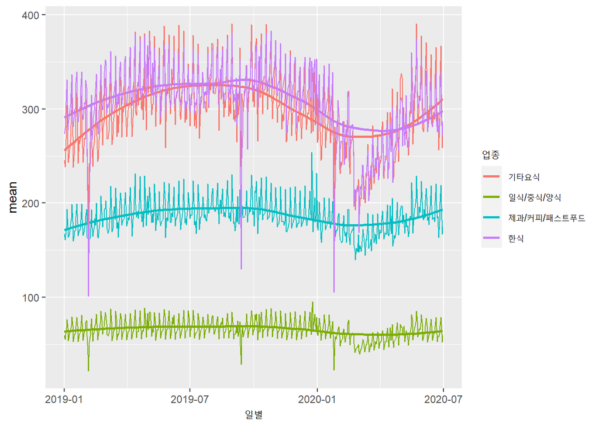

```r
shinhancard %>%
  group_by(일별, 업종) %>%
  summarise(mean = mean(`카드이용건수(천건)`)) %>%
  filter(업종 %in% c("한식", "일식/중식/양식",
                   "제과/커피/패스트푸드", "기타요식")) %>%
  ggplot(aes(x=일별)) +
  geom_smooth(aes(y=mean, colour = 업종), se= F) +
  geom_line(aes(y=mean, colour = 업종))
```

- group_by는 묶음 데이터를 개별의 데이터로 만들어 주기 위해 사용 합니다.
- summarise를 사용하여 하나의 행으로 축약 시키기 위해 사용 하고, 시계열 그래프를 만들기 위해 사용 합니다.
- filter는 업종내의 필요한 데이터를 추출하기 위해 사용 합니다.
- geom_smooth는 시계열 그래프의 평균열을 표시하기 위해 사용하고, se는 평균열 주위의 음양을 지우기 위해 사용 합니다.
- geom_line을 이용하여 구매건수를 시계열 그래프로 만들기 위해 사용 합니다.

#### 4-2)

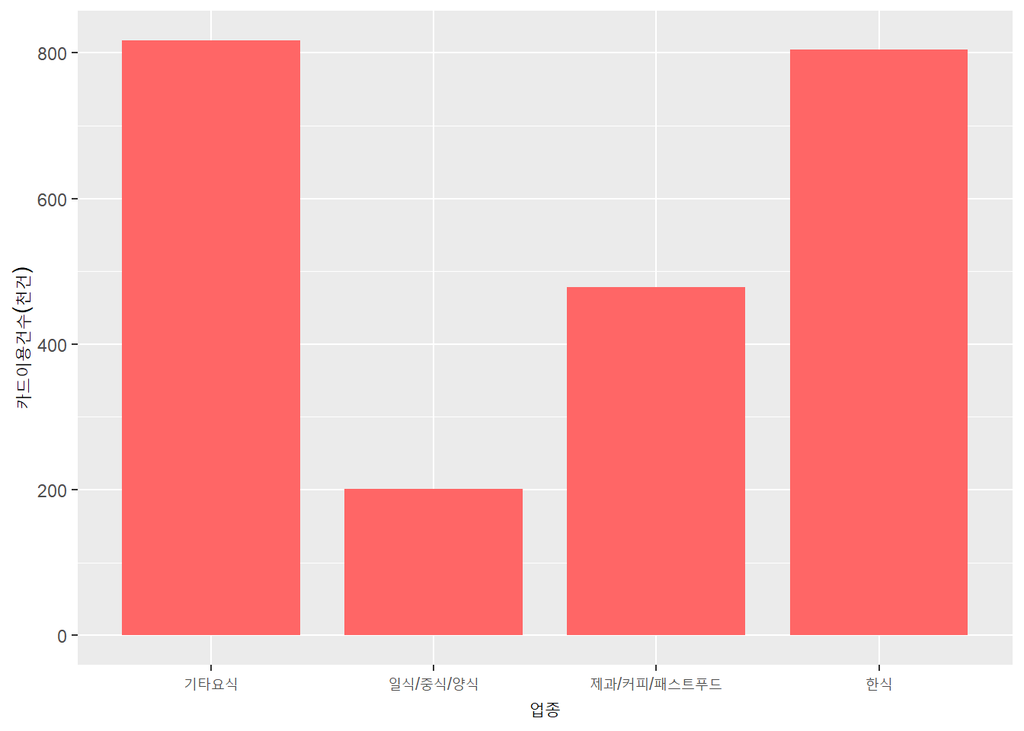

```r
shinhancard %>%
  group_by(업종, 일별) %>%
  count(`카드이용건수(천건)`) %>%
  filter(업종 %in% c("한식", "일식/중식/양식",
                   "제과/커피/패스트푸드", "기타요식")) %>%
  ggplot(aes(x = 업종, y= `카드이용건수(천건)`)) +
  geom_bar(stat = "identity", position= 'dodge', width=.8, fill= "#FF6666")
```

- count를 사용하여 y축 데이터를 카드이용건수 데이터로 적용 시킵니다.
- geom_bar를 이용하여 바형 그래프를 생성 합니다.
- stat는 y축에 지정된 데이터 대신 count에 입력한 데이터를 사용할 수 있게 하기위해서 사용 합니다.
- width를 사용 하면 그래프 간의 간격을 조정하기 위해 사용 합니다.

#### 4-3)

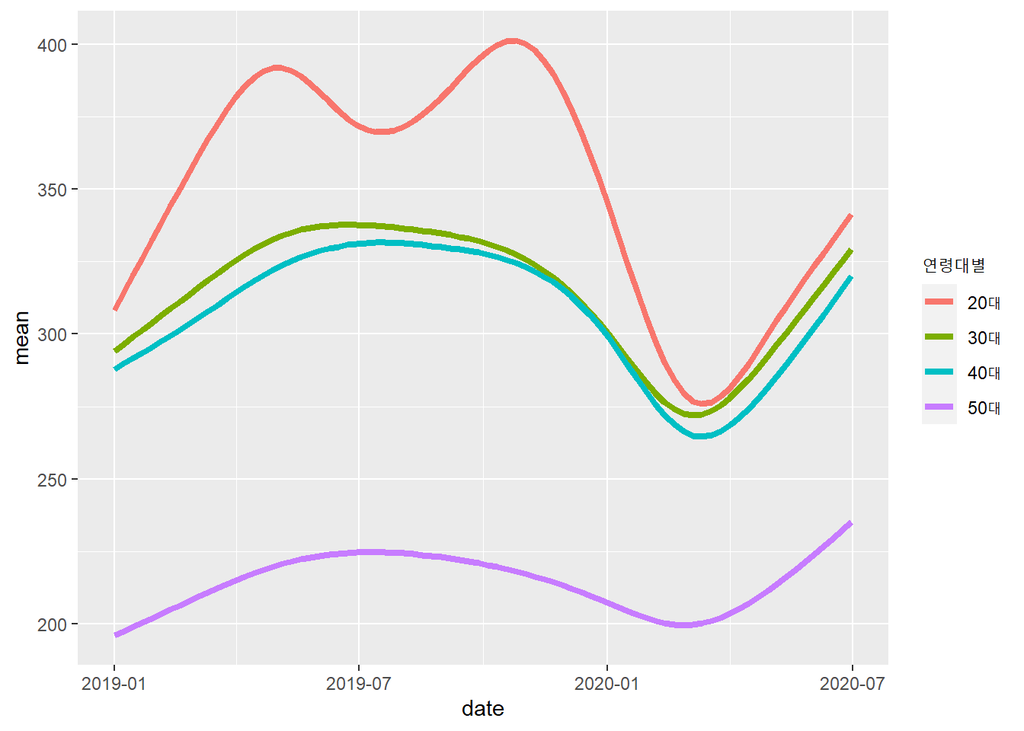

```r
shinhancard %>%
  rename(date = "일별") %>%
  group_by(date, 업종, 연령대별) %>%
  filter(연령대별 %in% c("20대", "30대", "40대", "50대")) %>%
  summarise(mean = mean(`카드이용건수(천건)`)) %>%
  filter(업종 %in% c("한식", "일식/중식/양식",
                   "제과/커피/패스트푸드", "기타요식")) %>%
  ggplot(aes(x=date)) +
  geom_smooth(aes(y=mean, colour = 연령대별),se=F, size=1.5)
```

- filter를 사용하여 연령대별 지출 현황을 묶어 줍니다.

#### 4-4)

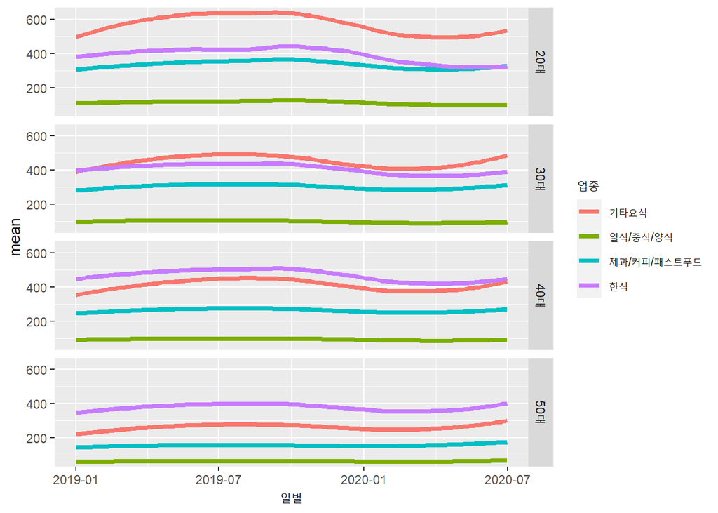

```r
shinhancard %>%
  group_by(일별, 업종, 연령대별) %>%
  filter(연령대별 %in% c("20대", "30대", "40대", "50대")) %>%
  summarise(mean = mean(`카드이용건수(천건)`)) %>%
  filter(업종 %in% c("한식", "일식/중식/양식",
                   "제과/커피/패스트푸드", "기타요식")) %>%
  ggplot(aes(x=일별)) +
  geom_smooth(aes(y=mean, colour = 업종),se=F, size=1.5) +
  facet_grid(연령대별 ~ .)
```

- facet_grid를 사용하여 각각의 연령대 별로 구분 합니다.

#### 4-5)

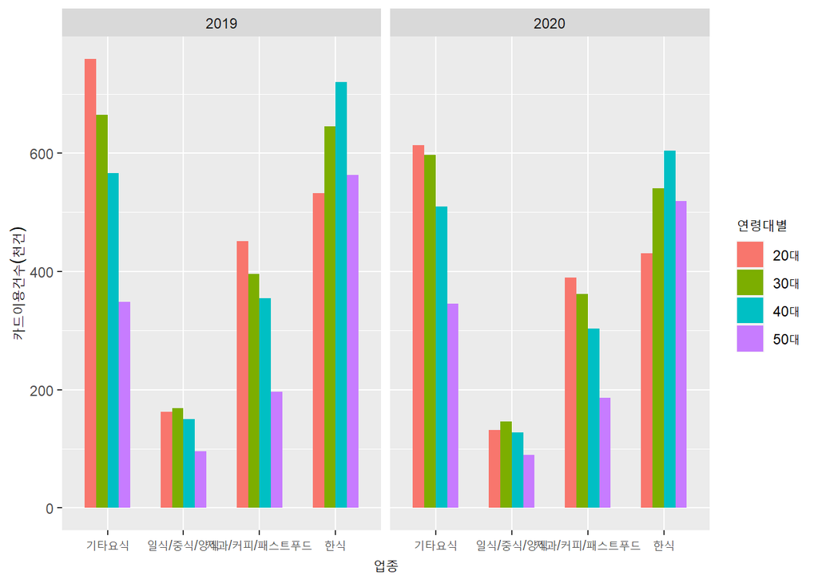

```r
shinhancard1 %>%
  group_by(일별, 업종, 연령대별, 코로나) %>%
  summarise(업종, `카드이용건수(천건)`) %>%
  filter(연령대별 %in% c("20대", "30대", "40대", "50대")) %>%
  filter(업종 %in% c("한식", "일식/중식/양식",
                   "제과/커피/패스트푸드", "기타요식")) %>%
  ggplot(aes(x = 업종, y= `카드이용건수(천건)`, fill= 연령대별)) +
  geom_bar(stat = "identity", position = 'dodge', width=.6) +
  facet_grid(. ~코로나)
```

- group_by에 새로운 변수 코로나를 추가해 줍니다. * 전후 비교를 위한 그래프를 생성하기 위해
- facet_grid를 사용하여 두개의 시트로 나눠 줍니다.

#### 4-6)

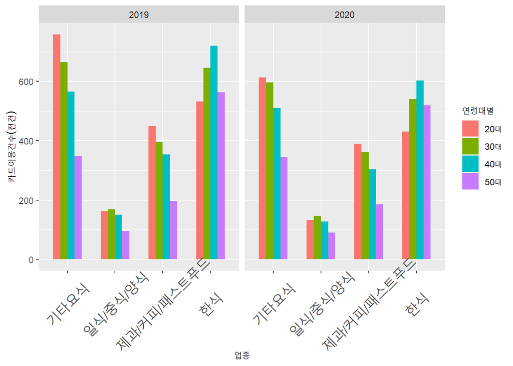

```r
shinhancard1 %>%    #코로나 전후 외식업종 연령별 구분(bar)
  group_by(일별, 업종, 연령대별, 코로나) %>%
  summarise(업종, `카드이용건수(천건)`) %>%
  filter(연령대별 %in% c("20대", "30대", "40대", "50대")) %>%
  filter(업종 %in% c("한식", "일식/중식/양식",
                   "제과/커피/패스트푸드", "기타요식")) %>%
  ggplot(aes(x = 업종, y= `카드이용건수(천건)`, fill= 연령대별)) +
  geom_bar(stat = "identity", position = 'dodge', width=.6) +
  facet_grid(. ~코로나) +
  theme(axis.text.x = element_text(angle=45, vjust=0.6, size = 12))
```

- x축의 항목이 겹치는 것을 방지 하기 위해 theme코드를 입력하고 angle로 각도를 지정해 줍니다.

#### 4-7)

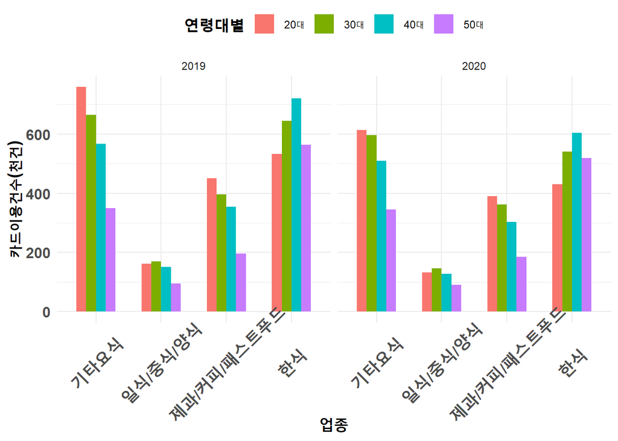

```r
shinhancard1 %>%
  group_by(일별, 업종, 연령대별, 코로나) %>%
  summarise(업종, `카드이용건수(천건)`) %>%
  filter(연령대별 %in% c("20대", "30대", "40대", "50대")) %>%
  filter(업종 %in% c("한식", "일식/중식/양식",
                   "제과/커피/패스트푸드", "기타요식")) %>%
  ggplot(aes(x = 업종, y= `카드이용건수(천건)`, fill= 연령대별)) +
  geom_bar(stat = "identity", position = 'dodge', width=.6) +
  facet_grid(. ~코로나) +
  theme_minimal() +
  theme(axis.text.x = element_text(angle=45, vjust=0.6, size = 12, face = "bold"),
        axis.text.y = element_text(size =12, face = 'bold'),
        axis.title=element_text(size=14, face='bold'),
        title = element_text(size=15, face='bold'),
        legend.position = "top")
```

- theme를 사용하여 x,y축의 글자 크기를 설정해 줍니다.
- 전, 후 그래프로 나누면서 카테고리박스로 인해 그래프 가독성에 영향을 주어 legend.position = “top”를 사용하여 그래프 위로 올려 줍니다.
- theme_minimal은 그래프의 디자인을 변경해 줍니다. https://ggplot2.tidyverse.org/reference/ggtheme.html

#### 4-8)

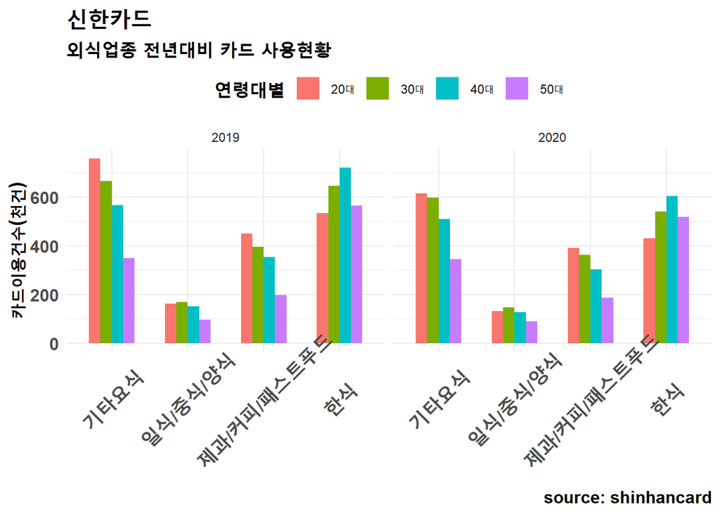

```r
shinhancard1 %>%
  group_by(일별, 업종, 연령대별, 코로나) %>%
  summarise(업종, `카드이용건수(천건)`) %>%
  filter(연령대별 %in% c("20대", "30대", "40대", "50대")) %>%
  filter(업종 %in% c("한식", "일식/중식/양식",
                   "제과/커피/패스트푸드", "기타요식")) %>%
  ggplot(aes(x = 업종, y= `카드이용건수(천건)`, fill= 연령대별)) +
  geom_bar(stat = "identity", position = 'dodge', width=.6) +
  facet_grid(. ~코로나) +
  theme_minimal() +
  theme(axis.text.x = element_text(angle=45, vjust=0.6, size = 12, face = "bold"),
        axis.text.y = element_text(size =12, face = 'bold'),
        axis.title=element_text(size=14, face='bold'),
        title = element_text(size=15, face='bold'),
        legend.position = "top") +
  labs(title="신한카드",
       subtitle="외식업종 전년대비 카드 사용현황",
       caption="source: shinhancard",
       x= " ")
```

- labs를 사용하여 그래프의 제목과 내용을 입력해 줍니다.

## 제출

[figure not shown]